# Tidying-up model results with broom

# Motivation

In R, model inputs are often tidy. However, model outputs are messy and inconsistent.

This is especially burdensome when working with many models at once (eg, running the same model on different subsets of data and comparing results).

For example, you need to extract p-values from a few regression models. Is this parameter called “pval”" or “PValue”?"

The solution is broom:

```
    The broom package takes the messy output of built-in functions in R,
    such as lm, nls, or t.test, and turns them into tidy data frames.
```

# Introductory Examples

```r
library(dplyr)
library(broom)
```

```r
df0 <- readRDS("data/inpatient_charges_2014_clean_cardiac_50plus.RDS")
```

```r
## You can tidy up lm output with tidy()
df0 %>%
    group_by(DRG.code) %>%
    do(
        tidy(lm(Average.Total.Payments ~ Total.Discharges, data=.))
    )
```

```
## Source: local data frame [58 x 6]
## Groups: DRG.code [29]
##
##    DRG.code             term    estimate  std.error statistic       p.value
##       <dbl>            <chr>       <dbl>      <dbl>     <dbl>         <dbl>
## 1       216      (Intercept) 68187.56385 1494.97268 45.611244 7.345751e-135
## 2       216 Total.Discharges   156.63305   42.74812  3.664092  2.947123e-04
## 3       217      (Intercept) 43953.47554 1251.78061 35.112763  3.046815e-67
## 4       217 Total.Discharges   124.36103   37.66967  3.301357  1.249531e-03
## 5       219      (Intercept) 55679.20035  781.41717 71.254130 2.075788e-256
## 6       219 Total.Discharges    69.15956   13.95518  4.955833  1.002196e-06
## 7       220      (Intercept) 36879.99038  502.79959 73.349285 2.630327e-282
## 8       220 Total.Discharges    37.31223    8.31120  4.489391  8.743602e-06
## 9       221      (Intercept) 32565.32564 1366.70979 23.827535  1.065700e-48
## 10      221 Total.Discharges   111.71605   61.17616  1.826137  7.017850e-02
## # ... with 48 more rows
```

```r
## You can review model fit with glance()
df0 %>%
    group_by(DRG.code) %>%
    do(
        glance(lm(Average.Total.Payments ~ Total.Discharges, data=.))
    ) %>%
  arrange(desc(adj.r.squared))
```

```
## Source: local data frame [29 x 12]
## Groups: DRG.code [29]
##
##    DRG.code  r.squared adj.r.squared     sigma statistic      p.value    df     logLik
##       <dbl>      <dbl>         <dbl>     <dbl>     <dbl>        <dbl> <int>      <dbl>
## 1       217 0.07903581   0.071784128  9592.548 10.898956 1.249531e-03     2  -1364.803
## 2       237 0.06516683   0.063721959 10649.373 45.102102 4.098939e-11     2  -6938.233
## 3       219 0.04896776   0.046973981 12164.456 24.560283 1.002196e-06     2  -5184.274
## 4       216 0.04395694   0.040682816 17668.665 13.425572 2.947123e-04     2  -3291.352
## 5       220 0.03610941   0.034317791  8394.474 20.154634 8.743602e-06     2  -5644.303
## 6       251 0.02607545   0.024457633  3894.000 16.117696 6.704277e-05     2  -5849.421
## 7       221 0.02558624   0.017913692  7531.402  3.334777 7.017850e-02     2  -1333.597
## 8       250 0.01595093   0.012411190  6957.467  4.506239 3.465518e-02     2  -2873.619
## 9       238 0.01291022   0.011924111  5362.785 13.092148 3.113609e-04     2 -10035.195
## 10      234 0.01097114   0.009365571  7653.704  6.833189 9.166691e-03     2  -6402.642
## # ... with 19 more rows, and 4 more variables: AIC <dbl>, BIC <dbl>, deviance <dbl>,
## #   df.residual <int>
```

# Concepts

Let’s learn to tidy up our model output with broom!

## 3 little functions that do a lot

```r
tidy()             #tidy up model output
glance()           #obtain one-row summary of model fit (R^2, AIC...)
augment()          #augment model output with more info (residuals, predictions, ...)
```

The output differs slightly depending on what model you run, but it strives for consistency. A p-value is always `p.value`.

```r
## prepare data
myvars <- c("Provider.Id", "DRG.code", "Average.Medicare.Payments",
            "Average.Covered.Charges", "Average.Total.Payments",
            "Total.Discharges", "Provider.State")
df <- df0 %>% select_(.dots=myvars)

## standard lm
lm(Average.Total.Payments ~ Total.Discharges, data=df)
```

```
##
## Call:
## lm(formula = Average.Total.Payments ~ Total.Discharges, data = df)
##
## Coefficients:
##      (Intercept)  Total.Discharges
##         19900.31            -40.01
```

```r
## lm summary()
lm(Average.Total.Payments ~ Total.Discharges, data=df) %>% summary
```

```
##
## Call:
## lm(formula = Average.Total.Payments ~ Total.Discharges, data = df)
##
## Residuals:
##    Min     1Q Median     3Q    Max
## -16820 -11251  -4833   5727 277596
##
## Coefficients:
##                  Estimate Std. Error t value Pr(>|t|)
## (Intercept)      19900.31     161.07  123.55   <2e-16 ***
## Total.Discharges   -40.01       3.89  -10.29   <2e-16 ***
## ---
## Signif. codes:  0 '***' 0.001 '**' 0.01 '*' 0.05 '.' 0.1 ' ' 1
##
## Residual standard error: 15680 on 22394 degrees of freedom
## Multiple R-squared:  0.004702,   Adjusted R-squared:  0.004657
## F-statistic: 105.8 on 1 and 22394 DF,  p-value: < 2.2e-16
```

```r
## tidy() results
lm(Average.Total.Payments ~ Total.Discharges, data=df) %>% tidy
```

```
##               term    estimate  std.error statistic      p.value
## 1      (Intercept) 19900.31277 161.069818 123.55085 0.000000e+00
## 2 Total.Discharges   -40.00608   3.889629 -10.28532 9.317356e-25
```

```r
## use glance() to see fit statistics (1 row/model)
lm(Average.Total.Payments ~ Total.Discharges, data=df) %>% summary %>% glance
```

```
##     r.squared adj.r.squared    sigma statistic      p.value df
## 1 0.004701723   0.004657278 15683.22  105.7878 9.317356e-25  2
```

```r
## augment() results to see predictions, clusters, etc
lm(Average.Total.Payments ~ Total.Discharges, data=df) %>% augment %>% tbl_df
```

```
## # A tibble: 22,396 × 9
##    Average.Total.Payments Total.Discharges  .fitted  .se.fit    .resid         .hat
##                     <dbl>            <int>    <dbl>    <dbl>     <dbl>        <dbl>
## 1                49868.00               11 19460.25 131.5575  30407.75 7.036571e-05
## 2                59623.00               21 19060.19 112.3989  40562.81 5.136340e-05
## 3                56985.50               16 19260.22 120.7982  37725.28 5.932680e-05
## 4                46413.43               14 19340.23 124.8499  27073.20 6.337331e-05
## 5                43955.62               13 19380.23 127.0061  24575.38 6.558109e-05
## 6                43870.05               22 19020.18 111.0520  24849.87 5.013977e-05
## 7                45485.10               31 18660.12 104.8116  26824.97 4.466309e-05
## 8               133149.64               14 19340.23 124.8499 113809.42 6.337331e-05
## 9                69618.83               41 18260.06 111.1904  51358.77 5.026481e-05
## 10               62393.64               11 19460.25 131.5575  42933.39 7.036571e-05
## # ... with 22,386 more rows, and 3 more variables: .sigma <dbl>, .cooksd <dbl>,
## #   .std.resid <dbl>
```

## do() from dplyr is a helper for broom

Recall that usually, dplyr returns a single value. We use `do()` when we aim to return something else.

Broom cleans up model outputs which return more than just a single value.

This is most useful when working with multiple models:

```r
df %>%
    group_by(DRG.code) %>%
    do(
        tidy(lm(Average.Total.Payments ~ Total.Discharges, data=.))
    )
```

```
## Source: local data frame [58 x 6]
## Groups: DRG.code [29]
##
##    DRG.code             term    estimate  std.error statistic       p.value
##       <dbl>            <chr>       <dbl>      <dbl>     <dbl>         <dbl>
## 1       216      (Intercept) 68187.56385 1494.97268 45.611244 7.345751e-135
## 2       216 Total.Discharges   156.63305   42.74812  3.664092  2.947123e-04
## 3       217      (Intercept) 43953.47554 1251.78061 35.112763  3.046815e-67
## 4       217 Total.Discharges   124.36103   37.66967  3.301357  1.249531e-03
## 5       219      (Intercept) 55679.20035  781.41717 71.254130 2.075788e-256
## 6       219 Total.Discharges    69.15956   13.95518  4.955833  1.002196e-06
## 7       220      (Intercept) 36879.99038  502.79959 73.349285 2.630327e-282
## 8       220 Total.Discharges    37.31223    8.31120  4.489391  8.743602e-06
## 9       221      (Intercept) 32565.32564 1366.70979 23.827535  1.065700e-48
## 10      221 Total.Discharges   111.71605   61.17616  1.826137  7.017850e-02
## # ... with 48 more rows
```

```r
## rewrite it a bit. note placement of %>%
df %>%
    group_by(DRG.code) %>%
    do(
        lm(Average.Total.Payments ~ Total.Discharges, data=.)
        %>%  tidy
    )
```

```
## Source: local data frame [58 x 6]
## Groups: DRG.code [29]
##
##    DRG.code             term    estimate  std.error statistic       p.value
##       <dbl>            <chr>       <dbl>      <dbl>     <dbl>         <dbl>
## 1       216      (Intercept) 68187.56385 1494.97268 45.611244 7.345751e-135
## 2       216 Total.Discharges   156.63305   42.74812  3.664092  2.947123e-04
## 3       217      (Intercept) 43953.47554 1251.78061 35.112763  3.046815e-67
## 4       217 Total.Discharges   124.36103   37.66967  3.301357  1.249531e-03
## 5       219      (Intercept) 55679.20035  781.41717 71.254130 2.075788e-256
## 6       219 Total.Discharges    69.15956   13.95518  4.955833  1.002196e-06
## 7       220      (Intercept) 36879.99038  502.79959 73.349285 2.630327e-282
## 8       220 Total.Discharges    37.31223    8.31120  4.489391  8.743602e-06
## 9       221      (Intercept) 32565.32564 1366.70979 23.827535  1.065700e-48
## 10      221 Total.Discharges   111.71605   61.17616  1.826137  7.017850e-02
## # ... with 48 more rows
```

```r
## augment it with more info
df %>%
    group_by(DRG.code) %>%
    do(
        lm(Average.Total.Payments ~ Total.Discharges, data=.)
        %>% augment %>% tidy
    )
```

```
## Source: local data frame [261 x 14]
## Groups: DRG.code [29]
##
##    DRG.code                 column     n          mean           sd        median
##       <dbl>                  <chr> <dbl>         <dbl>        <dbl>         <dbl>
## 1       216 Average.Total.Payments   294  7.215613e+04 1.803942e+04  6.796518e+04
## 2       216       Total.Discharges   294  2.533673e+01 2.414643e+01  1.750000e+01
## 3       216                .fitted   294  7.215613e+04 3.782129e+03  7.092864e+04
## 4       216                .se.fit   294  1.262349e+03 7.293624e+02  1.121203e+03
## 5       216                 .resid   294  4.170451e-13 1.763849e+04 -4.326200e+03
## 6       216                   .hat   294  6.802721e-03 2.256456e-02  4.026812e-03
## 7       216                 .sigma   294  1.766859e+04 6.505113e+01  1.768666e+04
## 8       216                .cooksd   294  2.847982e-03 9.056393e-03  8.637499e-04
## 9       216             .std.resid   294 -6.439654e-04 1.000959e+00 -2.453334e-01
## 10      217 Average.Total.Payments   129  4.700369e+04 9.956563e+03  4.514400e+04
## # ... with 251 more rows, and 8 more variables: trimmed <dbl>, mad <dbl>, min <dbl>,
## #   max <dbl>, range <dbl>, skew <dbl>, kurtosis <dbl>, se <dbl>
```

Of course, you can use other models: `glm()`, correlations, wilcoxon, other hypothesis tests.

```r
## example: correlations
df %>%
    group_by(DRG.code) %>%
    do(
        cor.test(.$Average.Total.Payments, .$Average.Medicare.Payments) %>% tidy
    )
```

```
## Source: local data frame [29 x 9]
## Groups: DRG.code [29]
##
##    DRG.code  estimate statistic       p.value parameter  conf.low conf.high
##       <dbl>     <dbl>     <dbl>         <dbl>     <int>     <dbl>     <dbl>
## 1       216 0.9352894  45.16239 9.225727e-134       292 0.9192473 0.9482306
## 2       217 0.9085970  24.51522  5.450751e-50       127 0.8728239 0.9346586
## 3       219 0.9208468  51.57816 3.132612e-197       477 0.9059999 0.9334305
## 4       220 0.8856615  44.24160 2.199678e-181       538 0.8660001 0.9025887
## 5       221 0.8854031  21.46616  4.433635e-44       127 0.8413073 0.9177931
## 6       226 0.8658425  14.98734  2.931131e-24        75 0.7962881 0.9128014
## 7       227 0.8787213  29.10702  2.910891e-82       250 0.8471356 0.9041194
## 8       233 0.8959942  42.22746 1.623017e-156       438 0.8758744 0.9130040
## 9       234 0.7380825  27.15050 2.369260e-107       616 0.6999594 0.7720114
## 10      235 0.8797131  28.66102  1.921839e-79       240 0.8476424 0.9053787
## # ... with 19 more rows, and 2 more variables: method <fctr>, alternative <fctr>
```

## Streamline workflow by saving models into data frame

```r
## assign lm output to new variable `fit`
(regressions <- df %>% group_by(DRG.code) %>%
    do(fit = lm(Average.Medicare.Payments ~ Total.Discharges, .)))
```

```
## Source: local data frame [29 x 2]
## Groups: <by row>
##
## # A tibble: 29 × 2
##    DRG.code      fit
## *     <dbl>   <list>
## 1       216 <S3: lm>
## 2       217 <S3: lm>
## 3       219 <S3: lm>
## 4       220 <S3: lm>
## 5       221 <S3: lm>
## 6       226 <S3: lm>
## 7       227 <S3: lm>
## 8       233 <S3: lm>
## 9       234 <S3: lm>
## 10      235 <S3: lm>
## # ... with 19 more rows
```

```r
regressions %>% tidy(fit)
```

```
## Source: local data frame [58 x 6]
## Groups: DRG.code [29]
##
##    DRG.code             term    estimate   std.error statistic       p.value
##       <dbl>            <chr>       <dbl>       <dbl>     <dbl>         <dbl>
## 1       216      (Intercept) 63393.24806 1325.743019 47.817146 3.815798e-140
## 2       216 Total.Discharges   111.79943   37.909067  2.949148  3.444175e-03
## 3       217      (Intercept) 40006.31913 1126.273378 35.520967  8.031475e-68
## 4       217 Total.Discharges   102.29156   33.892800  3.018091  3.074579e-03
## 5       219      (Intercept) 51946.88314  700.172043 74.191599 4.362062e-264
## 6       219 Total.Discharges    50.97673   12.504242  4.076755  5.349974e-05
## 7       220      (Intercept) 33081.17244  429.690524 76.988369 1.227053e-292
## 8       220 Total.Discharges    31.41505    7.102718  4.422962  1.178662e-05
## 9       221      (Intercept) 28817.16735 1229.672909 23.434823  5.966419e-48
## 10      221 Total.Discharges   105.15886   55.042162  1.910515  5.832126e-02
## # ... with 48 more rows
```

## Application: visualize p-values

```r
df2 <- df %>% filter(Provider.State %in% c("DC", "MD", "VA"))

(result <- df2 %>%
    group_by(DRG.code) %>%
    do(
        fit=lm(Average.Total.Payments ~ Total.Discharges + factor(Provider.State), data=.)
    ))
```

```
## Source: local data frame [29 x 2]
## Groups: <by row>
##
## # A tibble: 29 × 2
##    DRG.code      fit
## *     <dbl>   <list>
## 1       216 <S3: lm>
## 2       217 <S3: lm>
## 3       219 <S3: lm>
## 4       220 <S3: lm>
## 5       221 <S3: lm>
## 6       226 <S3: lm>
## 7       227 <S3: lm>
## 8       233 <S3: lm>
## 9       234 <S3: lm>
## 10      235 <S3: lm>
## # ... with 19 more rows
```

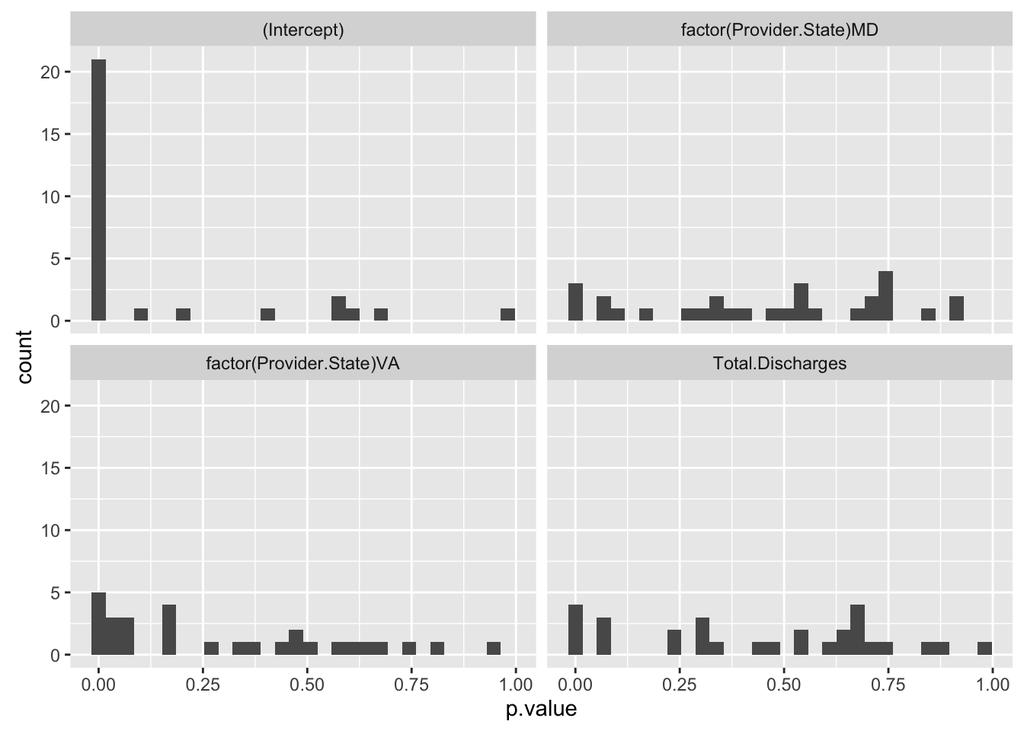

```r
library(ggplot2)
result %>% tidy(fit) %>% qplot(p.value, data=.) + facet_wrap(~term)
```

```r
## which DRG codes give the smallest p-value?
result %>% tidy(fit) %>% filter(term=="Total.Discharges") %>% arrange(p.value)
```

```
## Source: local data frame [29 x 6]
## Groups: DRG.code [29]
##
##    DRG.code             term    estimate std.error statistic      p.value
##       <dbl>            <chr>       <dbl>     <dbl>     <dbl>        <dbl>
## 1       237 Total.Discharges   481.18414  98.51047  4.884599 4.153115e-05
## 2       219 Total.Discharges   208.01169  54.83342  3.793520 1.594382e-03
## 3       251 Total.Discharges   115.29418  36.68274  3.143009 4.557658e-03
## 4       220 Total.Discharges    99.19749  35.50398  2.793982 1.087536e-02
## 5       280 Total.Discharges    39.57979  21.01791  1.883146 6.277250e-02
## 6       236 Total.Discharges    74.79415  38.66856  1.934237 6.547991e-02
## 7       235 Total.Discharges   419.00982 203.86049  2.055375 6.690345e-02
## 8       249 Total.Discharges    55.94950  45.19512  1.237955 2.267955e-01
## 9       234 Total.Discharges  -133.81764 112.18875 -1.192790 2.462549e-01
## 10      226 Total.Discharges -1001.11892 833.03061 -1.201779 2.957333e-01
## # ... with 19 more rows
```

```r
## Q: what is the "statistic"?
result %>% glance(fit) %>% arrange(desc(adj.r.squared))
```

```
## Source: local data frame [29 x 12]
## Groups: DRG.code [29]
##
##    DRG.code r.squared adj.r.squared    sigma statistic      p.value    df    logLik
##       <dbl>     <dbl>         <dbl>    <dbl>     <dbl>        <dbl> <int>     <dbl>
## 1       220 0.6925385     0.6486154 6713.384 15.767077 1.343611e-05     4 -253.5905
## 2       251 0.6068032     0.5555166 3412.545 11.831626 6.870256e-05     4 -255.7975
## 3       244 0.5809700     0.5460508 2933.228 16.637567 6.018540e-07     4 -374.0047
## 4       219 0.6158028     0.5437658 8409.516  8.548425 1.285525e-03     4 -206.8897
## 5       234 0.5441843     0.4790677 6335.724  8.357083 7.556327e-04     4 -252.1430
## 6       236 0.5362059     0.4757110 5364.728  8.863657 4.348276e-04     4 -268.0119
## 7       309 0.4556271     0.4397716 1368.727 28.736178 1.394236e-13     4 -922.5032
## 8       243 0.4615458     0.4230848 4699.381 12.000354 8.289525e-06     4 -452.1174
## 9       237 0.4757930     0.4175478 8044.409  8.168791 4.978178e-04     4 -320.6205
## 10      247 0.4376210     0.4069458 2958.435 14.266274 5.417602e-07     4 -553.1989
## # ... with 19 more rows, and 4 more variables: AIC <dbl>, BIC <dbl>, deviance <dbl>,
## #   df.residual <int>
```

```r
## you can easily filter the tidy output
result %>% filter(DRG.code==220) %>% tidy(fit)
```

```
## Source: local data frame [4 x 6]
## Groups: DRG.code [1]
##
##   DRG.code                     term    estimate  std.error statistic      p.value
##      <dbl>                    <chr>       <dbl>      <dbl>     <dbl>        <dbl>
## 1      220              (Intercept) 38402.10029 5146.62951  7.461602 2.469971e-07
## 2      220         Total.Discharges    99.19749   35.50398  2.793982 1.087536e-02
## 3      220 factor(Provider.State)MD  8597.68746 5252.41564  1.636902 1.165505e-01
## 4      220 factor(Provider.State)VA -7535.51870 5095.10376 -1.478973 1.539923e-01
```

# Summary

Use `broom`, along with `dplyr`, to improve your workflow. These three functions, which always return a data frame, will help you:

```r
tidy()             #tidy up model output
glance()           #return summary of model fit
augment()          #augment model output with more info (residuals, predictions) ( before tidy() )
```

In summary, with this workflow:

```
    a new class of analyses and visualizations becomes straightforward. This includes

    * Sorting by p-value or estimate to find the most significant terms across all tests
    * P-value histograms
    * Volcano plots comparing p-values to effect size estimates

    In each of these cases, we can easily filter, facet, or distinguish
    based on the term column. In short, this makes the tools of tidy data
    analysis available for the results of data analysis and models, not
    just the inputs.
```

# Exercises

1. Subset `df0` to provider “360006”, then summarize a linear regression for each DRG Code.
2. For each Provider, return top DRG.codes which provide best model fit, using a regression of Average.Total.Payment onto Provider.State and Total.Discharges.
3. (From module 1: Create a target y: 0/1, where 1 means Average.Total.Payments is greater than or equal to its mean across each DRG.code, and 0 otherwise). Run a logistic regression, and return model fit summaries.

# Advanced/Details

If time allows, go through this KMeans clustering vignette(): https://cran.r-project.org/web/packages/broom/vignettes/kmeans.html

See the `broom` conventions here:  
https://cran.r-project.org/web/packages/broom/vignettes/broom.html

Also, you can also look into the `purrr` package, which, among other things, can also make modeling easier:

```r
df %>%
    split(.$DRG.code) %>%
    map( ~ lm(Average.Medicare.Payments ~ Total.Discharges, data=.)) %>%
    map(summary) %>%
    #map_dbl("r.squared") %>%
    map("r.squared") %>%
    head
```

In `purrr`, also check out `map_at` and `map_if`.

Natrually, I’m excited that Hadley is now tackling modeling. See `modelr`: https://github.com/hadley/modelr